# 数据分析报告

## 0.数据准备

```python
import pandas as pd
import numpy as np
import matplotlib.pyplot as plt
import seaborn as sns
import os
import json
import pyecharts.options as opts
```

```python
# plt显示中文和负号，字体为宋体
plt.rcParams['font.sans-serif'] = ['SimHei']
plt.rcParams['axes.unicode_minus'] = False
```

```python
MACRO_REGION_MAP = {
    # North America
    "United States": "North America",
    "Canada": "North America",

    # East Asia
    "China": "East Asia",
    "Japan": "East Asia",
    "South Korea": "East Asia",
    "Singapore": "East Asia",

    # Europe
    "United Kingdom": "Europe",
    "Italy": "Europe",
    "Germany": "Europe",
    "France": "Europe",
    "Austria": "Europe",
    "Switzerland": "Europe",
    "Latvia": "Europe",
    "Belgium": "Europe",
    "Netherlands": "Europe",
    "Denmark": "Europe",
    "Finland": "Europe",
    "Sweden": "Europe",
    "Ireland": "Europe",
    "Norway": "Europe",
    "Czech Republic": "Europe",
    "Spain": "Europe",
    "Portugal": "Europe",
    "Poland": "Europe",
    "Greece": "Europe",

    # Middle East
    "Israel": "Middle East",
    "The United Arab Emirates": "Middle East",
    "Saudi Arabia": "Middle East",
    "Qatar": "Middle East",

    # Asia (Other)
    "India": "Other Asia",
    "Pakistan": "Other Asia",
    "Indonesia": "Other Asia",

    # Other Regions
    "Australia": "Other Regions",
    "New Zealand": "Other Regions",
    "Brazil": "Other Regions",
    "Chile": "Other Regions",
    "Tunisia": "Other Regions",
}
```

```python
# 数据来源于Aminer2023年的AI领域全球最具影响力的2000名学者A2000 读取JSON数据，并转换为DataFrame
def read_json_to_df(file_path):
    with open(file_path, 'r', encoding='utf-8') as file:
        data = json.load(file)
    df = pd.DataFrame(data)
    return df
```

```python
data = read_json_to_df('AI_2000_Scholars_in_2023.json')
```

```python
data
```

|  | domain | rank | name | gener | org | employer_type | region |
| --- | --- | --- | --- | --- | --- | --- | --- |
| 0 | {'en': 'AAAI/IJCAI', 'zh': 'AAAI/IJCAI'} | 1 | {'en': 'Christian Szegedy', 'zh': ''} | male | {'en': 'Google', 'zh': '谷歌'} | Industry | {'en': 'United States', 'zh': '美国'} |
| 1 | {'en': 'AAAI/IJCAI', 'zh': 'AAAI/IJCAI'} | 5 | {'en': 'Hado Philip Van Hasselt', 'zh': ''} | male | {'en': 'Google', 'zh': '谷歌'} | Industry | {'en': 'United States', 'zh': '美国'} |
| 2 | {'en': 'AAAI/IJCAI', 'zh': 'AAAI/IJCAI'} | 1 | {'en': 'Sergey Ioffe', 'zh': ''} | male | {'en': 'Google', 'zh': '谷歌'} | Industry | {'en': 'United States', 'zh': '美国'} |
| 3 | {'en': 'AAAI/IJCAI', 'zh': 'AAAI/IJCAI'} | 1 | {'en': 'Vincent Vanhoucke', 'zh': ''} | male | {'en': 'Google', 'zh': '谷歌'} | Industry | {'en': 'United States', 'zh': '美国'} |
| 4 | {'en': 'AAAI/IJCAI', 'zh': 'AAAI/IJCAI'} | 9 | {'en': 'Feiping Nie', 'zh': '聂飞平'} | male | {'en': 'Northwest Polytechnic University', 'zh... | Academia | {'en': 'China', 'zh': '中国'} |
| ... | ... | ... | ... | ... | ... | ... | ... |
| 1995 | {'en': 'Computer Networking', 'zh': '计算机网络'} | 12 | {'en': 'Stephen Stuart', 'zh': ''} | male | {'en': 'Google', 'zh': '谷歌'} | Industry | {'en': 'United States', 'zh': '美国'} |
| 1996 | {'en': 'Computer Networking', 'zh': '计算机网络'} | 77 | {'en': 'David A. Maltz', 'zh': ''} | male | {'en': 'Microsoft', 'zh': '微软'} | Industry | {'en': 'United States', 'zh': '美国'} |
| 1997 | {'en': 'Computer Networking', 'zh': '计算机网络'} | 45 | {'en': 'Gurudatta M. Parulkar', 'zh': ''} | male | {'en': 'Intel Corporation', 'zh': '英特尔'} | Industry | {'en': 'United States', 'zh': '美国'} |
| 1998 | {'en': 'Computer Networking', 'zh': '计算机网络'} | 45 | {'en': 'Bill Snow', 'zh': ''} | male | {'en': 'Intel Corporation', 'zh': '英特尔'} | Industry | {'en': 'United States', 'zh': '美国'} |
| 1999 | {'en': 'Computer Networking', 'zh': '计算机网络'} | 62 | {'en': 'Pavlin Radoslavov', 'zh': ''} | male | {'en': 'Google', 'zh': '谷歌'} | Industry | {'en': 'United States', 'zh': '美国'} |

2000 rows × 7 columns

## 1.数据清理

```python
# 对于domain、name、org、region都只保留字典内容中的zh字段
def extract_en(column):
    return column.apply(lambda x: x['en'] if isinstance(x, dict) and 'en' in x else x)
df = pd.DataFrame()
df['domain'] = extract_en(data['domain'])
df['rank'] = data['rank']
df['name'] = extract_en(data['name'])
df['gener'] = data['gener']
df['org'] = extract_en(data['org'])
df['employer_type'] = data['employer_type']
df['region'] = extract_en(data['region'])
```

```python
# 将所有空字符串替换为NaN
df.replace('', np.nan, inplace=True)
```

```python
df
```

|  | domain | rank | name | gener | org | employer_type | region |
| --- | --- | --- | --- | --- | --- | --- | --- |
| 0 | AAAI/IJCAI | 1 | Christian Szegedy | male | Google | Industry | United States |
| 1 | AAAI/IJCAI | 5 | Hado Philip Van Hasselt | male | Google | Industry | United States |
| 2 | AAAI/IJCAI | 1 | Sergey Ioffe | male | Google | Industry | United States |
| 3 | AAAI/IJCAI | 1 | Vincent Vanhoucke | male | Google | Industry | United States |
| 4 | AAAI/IJCAI | 9 | Feiping Nie | male | Northwest Polytechnic University | Academia | China |
| ... | ... | ... | ... | ... | ... | ... | ... |
| 1995 | Computer Networking | 12 | Stephen Stuart | male | Google | Industry | United States |
| 1996 | Computer Networking | 77 | David A. Maltz | male | Microsoft | Industry | United States |
| 1997 | Computer Networking | 45 | Gurudatta M. Parulkar | male | Intel Corporation | Industry | United States |
| 1998 | Computer Networking | 45 | Bill Snow | male | Intel Corporation | Industry | United States |
| 1999 | Computer Networking | 62 | Pavlin Radoslavov | male | Google | Industry | United States |

2000 rows × 7 columns

```python
df.info()
```

```
<class 'pandas.core.frame.DataFrame'>
RangeIndex: 2000 entries, 0 to 1999
Data columns (total 7 columns):
 #   Column         Non-Null Count  Dtype
---  ------         --------------  -----
 0   domain         2000 non-null   object
 1   rank           2000 non-null   int64
 2   name           2000 non-null   object
 3   gener          2000 non-null   object
 4   org            1992 non-null   object
 5   employer_type  1955 non-null   object
 6   region         1962 non-null   object
dtypes: int64(1), object(6)
memory usage: 109.5+ KB
```

可以发现所属机构、机构类型、所属地区三个字段存在缺失值

数据集包含7个字段，解释如下：

- domain: AI领域
- rank: 排名
- name: 学者姓名
- gener: 性别
- org: 所属机构
- employer_type: 机构类型
- region: 所属地区

## 2.描述性统计

```python
df['domain'].value_counts()
```

```
domain
AAAI/IJCAI               100
Theory                   100
Security and Privacy     100
HCI                      100
Visualization            100
Machine Learning         100
IR and Recommendation    100
Computer Vision          100
Data Mining              100
Knowledge Engineering    100
Computer Graphics        100
Speech Recognition       100
NLP                      100
Robotics                 100
Database                 100
Multimedia               100
Computer Systems         100
Internet of Things       100
Chip Technology          100
Computer Networking      100
Name: count, dtype: int64
```

一共20个AI领域，每个领域学者数量都为100，总计2000名学者。

```python
df.groupby('domain')['rank'].nunique()
```

```
domain
AAAI/IJCAI                92
Chip Technology           86
Computer Graphics         95
Computer Networking       85
Computer Systems          50
Computer Vision          100
Data Mining               79
Database                  82
HCI                       96
IR and Recommendation     81
Internet of Things        95
Knowledge Engineering     85
Machine Learning          99
Multimedia                81
NLP                      100
Robotics                  85
Security and Privacy      86
Speech Recognition        95
Theory                    90
Visualization             87
Name: rank, dtype: int64
```

其中只有Computer Vision领域和NLP领域的学者排位唯一，其余领域均有重复排名现象。

```python
df['name'].nunique()
```

```
1856
```

```python
# 新增唯一标识符
df['id'] = np.arange(1, len(df) + 1)
```

```python
df['gener'].value_counts()
```

```
gener
male      1826
female     174
Name: count, dtype: int64
```

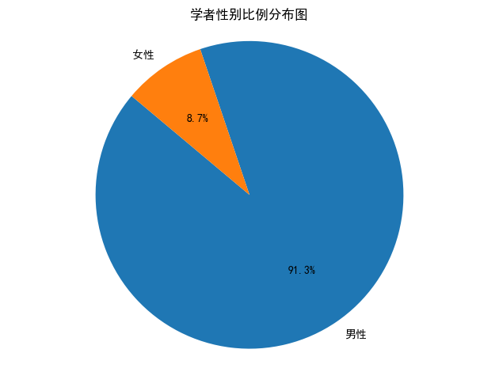

```python
# plt绘制男女比例饼图，显示百分比，标题为“性别比例分布图”
def plot_gender_distribution(df):
    gender_counts = df['gener'].value_counts()
    labels = gender_counts.index.tolist()
    sizes = gender_counts.values.tolist()
    # 设置清晰度
    _to_cn = {'male': '男性', 'female': '女性'}
    labels = [_to_cn.get(label, label) for label in labels]
    figure = plt.figure(dpi=100)
    ax = figure.add_subplot(111)
    ax.pie(sizes, labels=labels, autopct='%1.1f%%', startangle=140)
    ax.axis('equal')
    plt.title('学者性别比例分布图')
    plt.tight_layout()
    plt.savefig('gender_distribution.png')
    plt.show()
plot_gender_distribution(df)
```

男性学者占比远高于女性学者，男性学者有1826名，占比91.3%；女性学者有174名，占比8.7%。

```python
df['org'].value_counts().head(30)
```

```
org
Google                                             207
Microsoft                                           71
Meta                                                59
Massachusetts Institute of Technology               51
Carnegie Mellon University                          48
Stanford University                                 40
University of California, Berkeley                  37
Tsinghua University                                 33
University of Washington                            32
Amazon                                              23
DeepMind                                            23
Apple                                               22
Cornell University                                  19
National University of Singapore                    17
Zhejiang University                                 17
University of Michigan                              16
Georgia Institute of Technology                     16
Columbia University                                 15
University of California, San Diego                 15
Swiss Federal Institute of Technology in Zurich     15
New York University                                 15
University of Toronto                               14
The Chinese University of Hong Kong                 14
Peking University                                   13
Databricks                                          13
Princeton University                                13
University of Science and Technology of China       13
Federal Institute of Technology, Lausanne           12
Imperial College London                             11
University of Texas at Austin                       11
Name: count, dtype: int64
```

```python
df['org'].nunique()
```

```
611
```

```python
# 所属机构top15和其他机构数量
top15_org = df['org'].value_counts().head(15)
top15_org
```

```
org
Google                                   207
Microsoft                                 71
Meta                                      59
Massachusetts Institute of Technology     51
Carnegie Mellon University                48
Stanford University                       40
University of California, Berkeley        37
Tsinghua University                       33
University of Washington                  32
Amazon                                    23
DeepMind                                  23
Apple                                     22
Cornell University                        19
National University of Singapore          17
Zhejiang University                       17
Name: count, dtype: int64
```

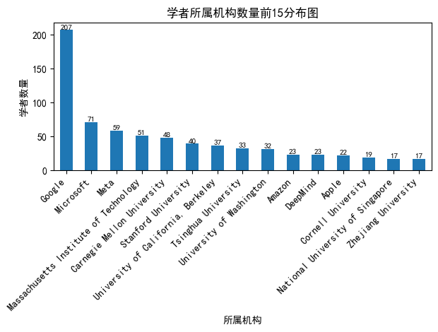

```python
# 前15所属机构绘制柱状图，显示数量，标题为“学者所属机构数量前15分布图”，横轴为“所属机构”，纵轴为“学者数量”，横轴倾斜45度，柱子内部显示具体数量
def plot_top15_org_distribution(top15_org):
    figure = plt.figure(dpi=100)
    ax = figure.add_subplot(111)
    top15_org.plot(kind='bar', ax=ax)
    plt.title('学者所属机构数量前15分布图')
    plt.xlabel('所属机构')
    plt.ylabel('学者数量')
    for i, v in enumerate(top15_org):
        ax.text(i, v, str(v), ha='center', va='bottom', fontsize=8)
    plt.xticks(rotation=45, ha='right')
    plt.tight_layout()
    plt.savefig('top15_org_distribution.png')
    plt.show()
plot_top15_org_distribution(top15_org)
```

```python
df['employer_type'].value_counts()
```

```
employer_type
Academia    1263
Industry     687
Other          5
Name: count, dtype: int64
```

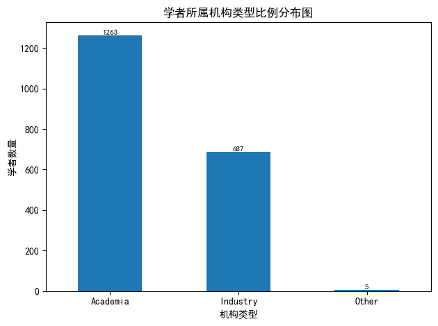

```python
# plt绘制所属机构类型柱状图，标题为“学者所属机构类型比例分布图”。横轴为“机构类型”，纵轴为“学者数量”，柱子上方显示具体数量，横轴标签水平显示
def plot_employer_type_distribution(df):
    employer_type_counts = df['employer_type'].value_counts()
    figure = plt.figure(dpi=100)
    ax = figure.add_subplot(111)
    employer_type_counts.plot(kind='bar', ax=ax)
    plt.title('学者所属机构类型比例分布图')
    plt.xlabel('机构类型')
    plt.ylabel('学者数量')
    for i, v in enumerate(employer_type_counts):
        ax.text(i, v, str(v), ha='center', va='bottom', fontsize=8)
    plt.xticks(rotation=0)
    plt.tight_layout()
    plt.savefig('employer_type_distribution.png')
    plt.show()

plot_employer_type_distribution(df)
```

```python
df['region'].unique()
```

```
array(['United States', 'China', 'South Korea', 'United Kingdom', 'Italy',
       'Singapore', 'Australia', 'United States; China', 'Canada',
       'United Kingdom; United States', 'Germany', 'Japan', 'Israel',
       'France', 'Austria', 'Switzerland', 'Latvia', 'Belgium',
       'Netherlands', 'Denmark', 'Finland', 'Sweden', 'Ireland',
       'New Zealand', 'Brazil', 'Norway', 'Czech', nan,
       'United States; South Korea', 'United Kingdom; France',
       'United States; Germany', 'Spain', 'United States; Australia',
       'United Kingdom; China', 'The United Arab Emirates', 'Chile',
       'Portuguese', 'Indonesia', 'China; Canada', 'Hellenic',
       'Saudi Arabia', 'Tunisia', 'Katar', 'Qatar', 'Poland', 'India',
       'United States; Singapore; Australia', 'Pakistan'], dtype=object)
```

```python
# 对于United States; Singapore; Australia这样的地区名称，进行拆分，每个地区拆成单独一条记录,在df基础上生成新的DataFrame：df_regions
df_regions = df.assign(region=df['region'].str.split('; ')).explode('region')
```

```python
df_regions['region'].value_counts()
```

```
region
United States               1131
China                        277
United Kingdom               114
Germany                      109
Canada                        61
Australia                     41
Singapore                     37
Switzerland                   32
France                        20
Japan                         18
Italy                         16
Netherlands                   15
Austria                       11
Israel                        11
Norway                        10
Sweden                        10
South Korea                    9
Spain                          7
Finland                        6
Denmark                        4
Ireland                        4
Belgium                        3
Portuguese                     3
Hellenic                       3
Brazil                         3
Czech                          3
Saudi Arabia                   3
New Zealand                    2
India                          2
The United Arab Emirates       2
Katar                          2
Chile                          2
Pakistan                       2
Latvia                         1
Indonesia                      1
Tunisia                        1
Poland                         1
Qatar                          1
Name: count, dtype: int64
```

```python
df_regions['region'].nunique()
```

```
38
```

```python
df_regions['region'].unique()
```

```
array(['United States', 'China', 'South Korea', 'United Kingdom', 'Italy',
       'Singapore', 'Australia', 'Canada', 'Germany', 'Japan', 'Israel',
       'France', 'Austria', 'Switzerland', 'Latvia', 'Belgium',
       'Netherlands', 'Denmark', 'Finland', 'Sweden', 'Ireland',
       'New Zealand', 'Brazil', 'Norway', 'Czech', nan, 'Spain',
       'The United Arab Emirates', 'Chile', 'Portuguese', 'Indonesia',
       'Hellenic', 'Saudi Arabia', 'Tunisia', 'Katar', 'Qatar', 'Poland',
       'India', 'Pakistan'], dtype=object)
```

一共611个不同的所属机构，机构类型有3种，所属地区有38个不同地区。

```python
def clean_region(r):
    if pd.isna(r):
        return np.nan
    r = r.strip()
    if r in ["Qatar", "Katar"]:
        return "Qatar"
    if r == "Portuguese":
        return "Portugal"
    if r == "Hellenic":
        return "Greece"
    if r == "Czech":
        return "Czech Republic"
    return r

df_regions["region_clean"] = df_regions["region"].apply(clean_region)
```

```python
top15_regions = df_regions['region_clean'].value_counts().head(15)
top15_regions
```

```
region_clean
United States     1131
China              277
United Kingdom     114
Germany            109
Canada              61
Australia           41
Singapore           37
Switzerland         32
France              20
Japan               18
Italy               16
Netherlands         15
Austria             11
Israel              11
Sweden              10
Name: count, dtype: int64
```

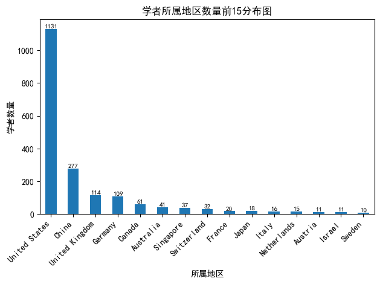

```python
def plot_top_orgs_distribution(top15_regions):
    figure = plt.figure(dpi=100)
    ax = figure.add_subplot(111)
    top15_regions.plot(kind='bar', ax=ax)
    plt.title('学者所属地区数量前15分布图')
    plt.xlabel('所属地区')
    plt.ylabel('学者数量')
    for i, v in enumerate(top15_regions):
        ax.text(i, v, str(v), ha='center', va='bottom', fontsize=8)
    plt.xticks(rotation=45, ha='right')
    plt.tight_layout()
    plt.savefig('top15_regions_distribution.png')
    plt.show()

plot_top_orgs_distribution(top15_regions)
```

为提高可视化与结构分析的可解释性，本文在国家层级数据基础上构建了宏区域分类，将研究对象划分为北美、东亚、欧洲、中东、其他亚洲及其他地区。由于其他亚洲数量较少，将其划分到东亚类别中。

```python
def map_macro_region(r):
    if pd.isna(r):
        return None
    return MACRO_REGION_MAP.get(r, "Other Regions")

df_regions["macro_region"] = df_regions["region_clean"].apply(map_macro_region)
```

```python
df_regions["macro_region"].value_counts(dropna=False)
```

```
macro_region
North America    1192
Europe            372
East Asia         341
Other Regions      49
None               38
Middle East        19
Other Asia          5
Name: count, dtype: int64
```

```python
# 由于其他亚洲数量较少，将其划分到东亚类别中
df_regions['macro_region'] = df_regions['macro_region'].replace('Other Asia', 'East Asia')
```

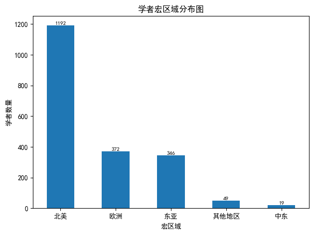

```python
def plot_macro_region_distribution(df_regions):
    region_counts = df_regions['macro_region'].value_counts(dropna=True)
    figure = plt.figure(dpi=100)
    ax = figure.add_subplot(111)
    region_counts.plot(kind='bar', ax=ax)
    plt.title('学者宏区域分布图')
    plt.xlabel('宏区域')
    plt.ylabel('学者数量')
    for i, v in enumerate(region_counts):
        ax.text(i, v, str(v), ha='center', va='bottom', fontsize=8)
    # 横轴标签换成中文并水平显示
    _to_cn = {
        "North America": "北美",
        "East Asia": "东亚",
        "Europe": "欧洲",
        "Middle East": "中东",
        "Other Asia": "其他亚洲",
        "Other Regions": "其他地区"
    }
    labels = [_to_cn.get(label, label) for label in region_counts.index.tolist()]
    ax.set_xticklabels(labels)
    plt.xticks(rotation=0)
    plt.tight_layout()
    plt.savefig('region_distribution.png')
    plt.show()

plot_macro_region_distribution(df_regions)
```

## 3.数据分析与可视化

```python
def hhi(series):
    p = series / series.sum()
    return (p ** 2).sum()

def entropy(series):
    p = series / series.sum()
    return -(p * np.log(p + 1e-12)).sum()

def gini(array):
    array = np.sort(array)
    n = len(array)
    cum = np.cumsum(array)
    return (n + 1 - 2 * np.sum(cum) / cum[-1]) / n
```

### 3.1 AI 顶尖人才的全球分布版图

```python
from pyecharts.charts import Map

map_chart = (
    Map()
    .add(
        series_name="学者数量",
        data_pair=[(region, int(count)) for region, count in df_regions['region_clean'].value_counts().items()],
        maptype="world",
        is_map_symbol_show=False,
        label_opts=opts.LabelOpts(is_show=False),  # 隐藏国家名称标签
    )
    .set_global_opts(
        legend_opts=opts.LegendOpts(is_show=False),
        title_opts=opts.TitleOpts(title="AI 顶尖人才全球分布图"),
        visualmap_opts=opts.VisualMapOpts(
            min_=0,
            max_=df_regions['region_clean'].value_counts().max(),
            is_piecewise=True,
            pieces=[
                {"min": 100, "label": ">100", "color": "#800026"},
                {"min": 50, "max": 99, "label": "50-99", "color": "#BD0026"},
                {"min": 20, "max": 49, "label": "20-49", "color": "#E31A1C"},
                {"min": 10, "max": 19, "label": "10-19", "color": "#FC4E2A"},
                {"min": 1, "max": 9, "label": "1-9", "color": "#FD8D3C"},
                {"max": 0, "label": "0", "color": "#FFEDA0"},
            ],
        ),
    )
)

map_chart.render_notebook()
```

```python
map_chart.render("ai_scholars_global_distribution.html")
```

```
'C:\\Projects\\python\\AI2000\\ai_scholars_global_distribution.html'
```

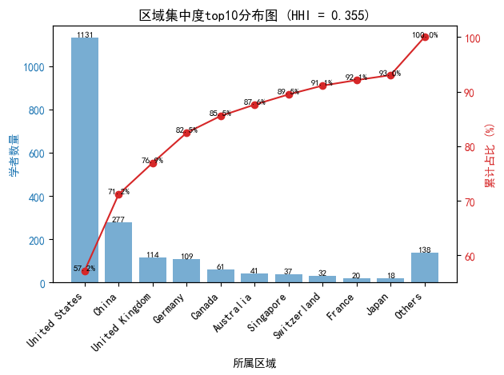

```python
# 绘制区域集中度图表，显示前top_k个区域的学者数量和累计占比曲线，标题为“区域集中度分布图”，横轴为“所属区域”，左纵轴为“学者数量”，右纵轴为“累计占比”，并在标题中显示HHI指数值，保留三位小数，横轴标签倾斜45度，柱子上方显示具体数量，累计占比曲线上显示具体百分比
def fig1_region_concentration(df_regions, top_k=10, region_col='region_clean'):
    region_counts = df_regions[region_col].value_counts(dropna=True)
    top_regions = region_counts.head(top_k)
    # 其他区域合并为“其他”
    if len(region_counts) > top_k:
        other_count = region_counts[top_k:].sum()
        top_regions['Others'] = other_count
    cumulative_counts = top_regions.cumsum()
    cumulative_percentage = cumulative_counts / cumulative_counts.iloc[-1] * 100

    fig, ax1 = plt.subplots(dpi=100)

    color = 'tab:blue'
    ax1.set_xlabel('所属区域')
    ax1.set_ylabel('学者数量', color=color)
    bars = ax1.bar(top_regions.index, top_regions.values, color=color, alpha=0.6)
    # print(top_regions.index, top_regions.values)
    ax1.tick_params(axis='y', labelcolor=color)
    plt.xticks(rotation=45, ha='right')

    for bar in bars:
        height = bar.get_height()
        ax1.text(bar.get_x() + bar.get_width() / 2, height, str(height), ha='center', va='bottom', fontsize=8)

    ax2 = ax1.twinx()
    color = 'tab:red'
    ax2.set_ylabel('累计占比 (%)', color=color)
    line, = ax2.plot(top_regions.index, cumulative_percentage.values, color=color, marker='o')
    # print(cumulative_percentage.index, cumulative_percentage.values)
    ax2.tick_params(axis='y', labelcolor=color)
    for i, v in enumerate(cumulative_percentage):
        ax2.text(i, v, f"{v:.1f}%", ha='center', va='bottom', fontsize=8)

    plt.title(f"区域集中度top{top_k}分布图 (HHI = {hhi(region_counts):.3f})")

    fig.tight_layout()
    plt.savefig('region_concentration.png')
    plt.show()

fig1_region_concentration(df_regions)
```

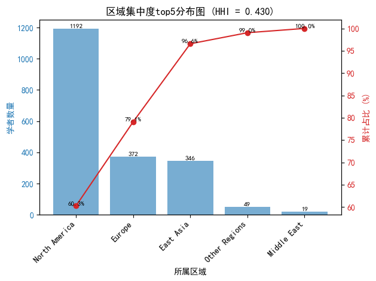

```python
fig1_region_concentration(df_regions, top_k=5, region_col='macro_region')
```

从国家层面来看，AI 2000 学者在全球范围内呈现明显的集中趋势。美国独占57%的学者，中国占比约14%（累积约71%），前三个国家（美国、中国、英国）就拥有超过三分之二的学者。其余国家分布较为分散，尤其是“其他国家”合计约占6.9%。

通过计算HHI（0.355）可以量化这一集中度，说明学者资源在国家层面呈现中等偏高的集中格局，少数国家拥有大部分顶尖学者。

HHI 为0.430，高于国家层面的0.355，说明从区域层面看，学者分布更为集中，主要集中在北美、欧洲和东亚三大区域，而其他区域的学者相对稀少。

综合来看，无论从国家还是宏观区域分析，AI 2000 学者分布都呈现明显的集中趋势。 少数国家和区域拥有大部分顶尖学者，表明全球AI顶尖人才资源分布不均衡，集中在少数发达国家和地区。

### 3.2 不同领域的全球化程度

```
Computer Networking      0.626548
Speech Recognition       0.943189
NLP                      1.024073
Computer Systems         1.026029
HCI                      1.143912
Theory                   1.156999
Machine Learning         1.239167
Computer Vision          1.293941
Chip Technology          1.302547
Data Mining              1.422028
Security and Privacy     1.425503
Database                 1.482324
AAAI/IJCAI               1.503198
Robotics                 1.516005
Multimedia               1.583357
IR and Recommendation    1.622304
Computer Graphics        1.676818
Visualization            1.774261
Internet of Things       2.142988
Knowledge Engineering    2.494597
dtype: float64
```

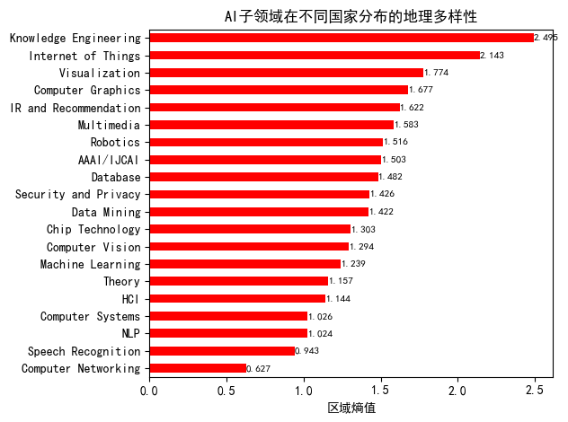

```python
# 计算领域在各区域的熵值，并绘制水平柱状图，标题为“AI各子领域的地理多样性”，横轴为“区域熵值”，按熵值从低到高排序
def fig2_domain_macro_entropy(df):
    entropies = {}

    for domain, g in df.groupby("domain"):
        entropies[domain] = entropy(
            g["region_clean"].value_counts()
        )

    entropies_series = pd.Series(entropies).sort_values()
    print(entropies_series)

    plt.figure(dpi=100)
    ax = entropies_series.plot(kind='barh', color='red')
    plt.xlabel('区域熵值')
    plt.title('AI子领域在不同国家分布的地理多样性')
    for i, v in enumerate(entropies_series):
        ax.text(v, i, f"{v:.3f}", ha='left', va='center', fontsize=8)
    plt.tight_layout()
    plt.savefig('domain_region_entropy.png')
    plt.show()

fig2_domain_macro_entropy(df_regions)
```

领域全球化程度：熵值越高，表示该AI子领域学者的地理分布越均匀（多样性高），即学者分布在更多国家或宏区域中，说明该领域更具全球性，不依赖特定地区资源。例如，高熵领域可能受益于国际合作和广泛的人才流动。熵值越低，表示集中度高，学者主要集中在少数国家或宏区域，可能受当地政策、教育或产业影响

### 3.3 不同机构中学者是否存在显著差异

```python
# 将employer_type列中的'Other'替换成None，生成新的DataFrame：df_emtype
def add_domain_normalized_rank_score(df):
    df = df.copy()

    def normalize(group):
        max_rank = group['rank'].max()
        if max_rank == 1:
            group['rank_score'] = 1.0
        else:
            group['rank_score'] = 1 - (group['rank'] - 1) / (max_rank - 1)
        return group

    df = df.groupby('domain', group_keys=False).apply(normalize)
    return df

df = add_domain_normalized_rank_score(df)
df_emtype = df.copy()
df_emtype['employer_type'] = df_emtype['employer_type'].replace('Other', None)
df_emtype = df_emtype.dropna(subset=['employer_type'])
```

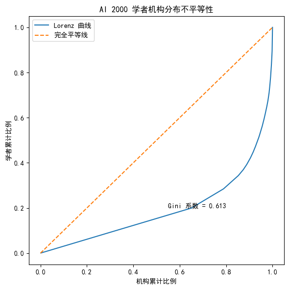

```python
import numpy as np

def compute_gini(values):
    values = np.array(values)
    values = values[values >= 0]
    values = np.sort(values)
    n = len(values)
    cumvals = np.cumsum(values)
    gini = (n + 1 - 2 * np.sum(cumvals) / cumvals[-1]) / n
    return gini

def plot_org_lorenz_curve(df):
    org_counts = df['org'].value_counts().values
    sorted_counts = np.sort(org_counts)

    cum_orgs = np.arange(1, len(sorted_counts) + 1) / len(sorted_counts)
    cum_scholars = np.cumsum(sorted_counts) / sorted_counts.sum()

    gini = compute_gini(org_counts)

    plt.figure(figsize=(6, 6), dpi=100)
    plt.plot(cum_orgs, cum_scholars, label='Lorenz 曲线')
    plt.plot([0, 1], [0, 1], '--', label='完全平等线')
    plt.text(0.55, 0.2, f'Gini 系数 = {gini:.3f}')
    plt.xlabel('机构累计比例')
    plt.ylabel('学者累计比例')
    plt.title('AI 2000 学者机构分布不平等性')
    plt.legend()
    plt.tight_layout()
    plt.show()

plot_org_lorenz_curve(df)
```

Lorenz 曲线明显偏离完全平等线，Gini 系数较高，说明 AI 2000 学者在机构层面存在较强的不平等现象，即少数机构聚集了大量高影响力学者。

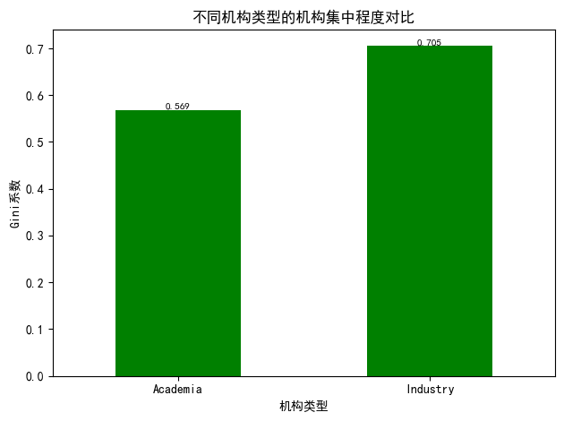

```python
# 计算不同机构类型的Gini系数，并绘制柱状图，标题为“不同机构类型的机构集中程度对比”，横轴为“机构类型”，纵轴为“Gini系数”, 柱子上方显示具体Gini系数值，保留三位小数,横轴标签水平显示
def plot_gini_by_employer_type(df):
    gini_values = {}
    for em_type, group in df.groupby('employer_type'):
        org_counts = group['org'].value_counts().values
        gini_values[em_type] = compute_gini(org_counts)

    gini_series = pd.Series(gini_values).sort_values()

    plt.figure(dpi=100)
    ax = gini_series.plot(kind='bar', color='green')
    plt.xlabel('机构类型')
    plt.ylabel('Gini系数')
    plt.title('不同机构类型的机构集中程度对比')
    plt.xticks(rotation=0)
    for i, v in enumerate(gini_series):
        ax.text(i, v, f"{v:.3f}", ha='center', va='bottom', fontsize=8)
    plt.tight_layout()
    plt.savefig('gini_by_employer_type.png')
    plt.show()
plot_gini_by_employer_type(df_emtype)
```

结果显示，产业界的机构集中程度明显高于学界，说明 AI 领域的产业研究力量更容易集中于少数大型企业，而高校和科研机构的分布相对更加分散。

```
T检验结果: statistic=1.4721954680973728, p-value=0.14112963725184144
```

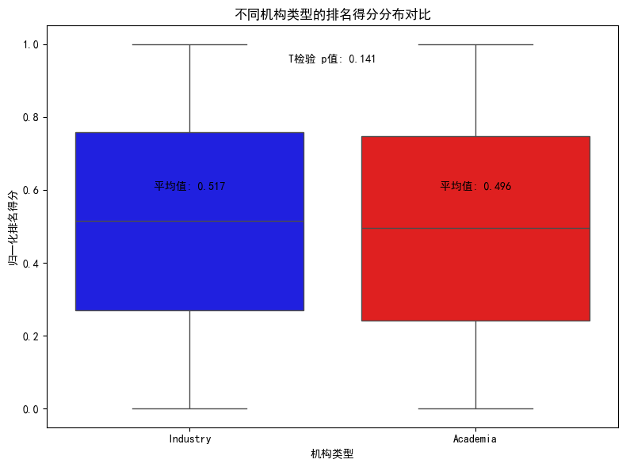

```python
# 箱线图，蓝色和红色表示不同类型的排名得分，再标注统计检验结果，分数是否与机构类型有关，标注不同类型的平均值
def plot_rank_score_by_employer_type(df):
    import scipy.stats as stats

    plt.figure(figsize=(8, 6))
    ax = sns.boxplot(x='employer_type', y='rank_score', data=df, hue='employer_type', palette=['blue', 'red'], legend=False)
    means = df.groupby('employer_type')['rank_score'].mean()
    # means的顺序调整为Industry在前，Academia在后
    means = means.reindex(['Industry', 'Academia'])
    # 字体位置y轴保持一致
    for i, (etype, mean) in enumerate(means.items()):
        plt.text(i, 0.6, f'平均值: {mean:.3f}', ha='center', color='black')

    plt.xlabel('机构类型')
    plt.ylabel('归一化排名得分')
    plt.title('不同机构类型的排名得分分布对比')

    types = df['employer_type'].unique()
    if len(types) == 2:
        group1 = df[df['employer_type'] == types[0]]['rank_score']
        group2 = df[df['employer_type'] == types[1]]['rank_score']
        stat, p_value = stats.ttest_ind(group1, group2, nan_policy='omit')
        print(f'T检验结果: statistic={stat}, p-value={p_value}')
        plt.text(0.5, max(df['rank_score']) * 0.95, f'T检验 p值: {p_value:.3}', ha='center')

    plt.tight_layout()
    plt.savefig('rank_score_by_employer_type.png')
    plt.show()

plot_rank_score_by_employer_type(df_emtype)
```

从图中可以看出，产业界学者的排名得分均值略高于学界，但检验结果 p = 0.141，表明两类机构之间的排名得分差异在统计上不显著。这说明机构类型对学者排名水平的影响有限，两类机构均有高排名学者存在。尽管产业界平均排名略高，但统计检验未显示显著差异，说明排名更多取决于个体研究能力和领域因素，而非机构类型本身。

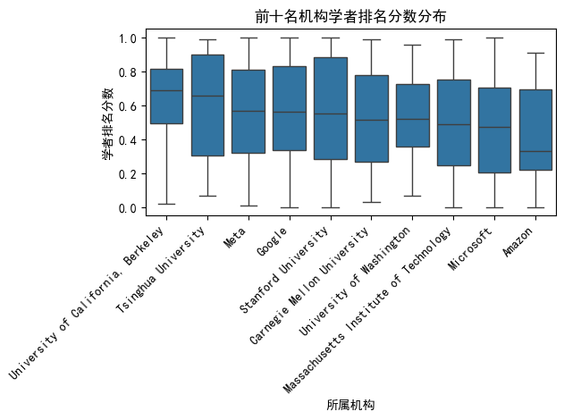

```python
# 对前十名机构的学者排名分数进行箱线图绘制，标题为“前十名机构学者排名分数分布”，横轴为“所属机构”，纵轴为“学者排名分数”，横轴标签倾斜45度，按平均排名分数从高到低排序
def plot_top10_org_rank_boxplot(df):
    top10_orgs = df['org'].value_counts().head(10).index
    df_top10 = df[df['org'].isin(top10_orgs)]

    order = df_top10.groupby('org')['rank_score'].mean().sort_values(ascending=False).index

    plt.figure(dpi=100)
    ax = sns.boxplot(x='org', y='rank_score', data=df_top10, order=order)
    plt.title('前十名机构学者排名分数分布')
    plt.xlabel('所属机构')
    plt.ylabel('学者排名分数')
    plt.xticks(rotation=45, ha='right')
    plt.tight_layout()
    plt.savefig('top10_org_rank_boxplot.png')
    plt.show()
plot_top10_org_rank_boxplot(df)
```

### 3.4 AI领域中的性别优势

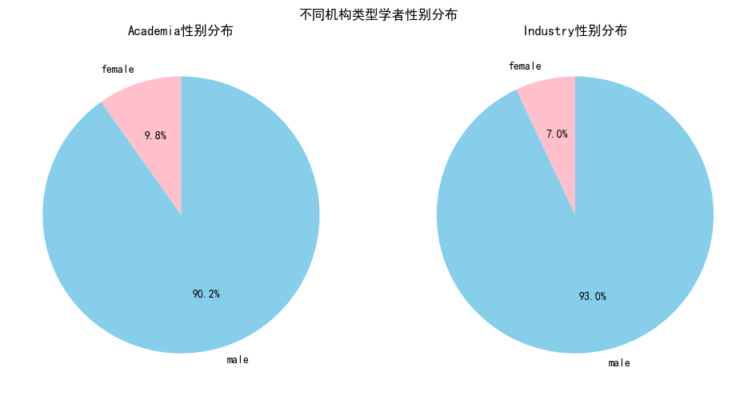

```python
# 不同机构类型学者性别分布，两个饼图，颜色'skyblue', 'pink'
def plot_gender_by_employer_type(df):
    gender_by_type = df.groupby('employer_type')['gener'].value_counts().unstack().fillna(0)
    fig, axes = plt.subplots(1, 2, figsize=(10, 5), dpi=100)
    colors = ['pink', 'skyblue']
    for ax, (em_type, counts) in zip(axes, gender_by_type.iterrows()):
        labels = counts.index.tolist()
        sizes = counts.values.tolist()
        ax.pie(sizes, labels=labels, autopct='%1.1f%%', startangle=90, colors=colors)
        ax.set_title(f'{em_type}性别分布')
    plt.suptitle('不同机构类型学者性别分布')
    plt.tight_layout()
    plt.savefig('gender_by_employer_type.png')
    plt.show()
plot_gender_by_employer_type(df_emtype)
```

在学界机构中，男性学者占绝大多数，女性学者比例略高于产业界。产业界学者中男性比例更高，女性学者较少。这表明性别比例差异在机构类型间存在一定的结构性特点，但在学术界这种差异相对较小，更具包容性，可能与学术界相对开放的文化和政策有关。

```python
df
```

|  | domain | rank | name | gener | org | employer_type | region | id | rank_score |
| --- | --- | --- | --- | --- | --- | --- | --- | --- | --- |
| 0 | AAAI/IJCAI | 1 | Christian Szegedy | male | Google | Industry | United States | 1 | 1.000000 |
| 1 | AAAI/IJCAI | 5 | Hado Philip Van Hasselt | male | Google | Industry | United States | 2 | 0.959596 |
| 2 | AAAI/IJCAI | 1 | Sergey Ioffe | male | Google | Industry | United States | 3 | 1.000000 |
| 3 | AAAI/IJCAI | 1 | Vincent Vanhoucke | male | Google | Industry | United States | 4 | 1.000000 |
| 4 | AAAI/IJCAI | 9 | Feiping Nie | male | Northwest Polytechnic University | Academia | China | 5 | 0.919192 |
| ... | ... | ... | ... | ... | ... | ... | ... | ... | ... |
| 1995 | Computer Networking | 12 | Stephen Stuart | male | Google | Industry | United States | 1996 | 0.888889 |
| 1996 | Computer Networking | 77 | David A. Maltz | male | Microsoft | Industry | United States | 1997 | 0.232323 |
| 1997 | Computer Networking | 45 | Gurudatta M. Parulkar | male | Intel Corporation | Industry | United States | 1998 | 0.555556 |
| 1998 | Computer Networking | 45 | Bill Snow | male | Intel Corporation | Industry | United States | 1999 | 0.555556 |
| 1999 | Computer Networking | 62 | Pavlin Radoslavov | male | Google | Industry | United States | 2000 | 0.383838 |

2000 rows × 9 columns

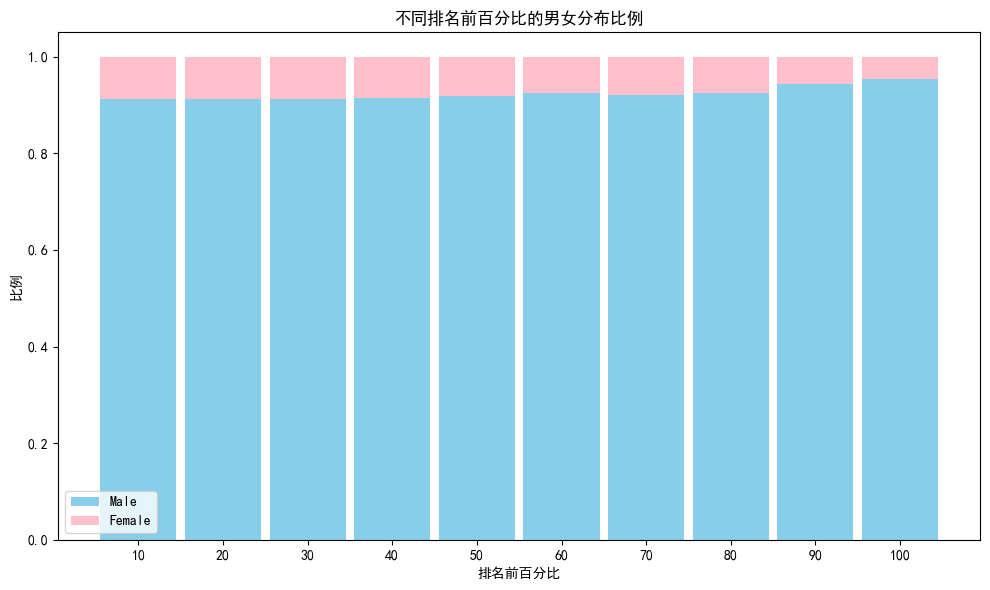

```python
def plot_gender_distribution_by_rank_percentiles(df):
    percentiles = np.arange(0.1, 1.1, 0.1)
    gender_percentiles = []
    for p in percentiles:
        threshold = df['rank_score'].quantile(p)
        subset = df[df['rank_score'] >= threshold]
        gender_dist = subset['gener'].value_counts(normalize=True)
        gender_percentiles.append(gender_dist)
    return gender_percentiles
gender_percentiles = plot_gender_distribution_by_rank_percentiles(df)
def plot_gender_percentiles(gender_percentiles):
    percentiles = np.arange(10, 110, 10)
    plt.figure(figsize=(10, 6))
    for i, gender_dist in enumerate(gender_percentiles):
        plt.bar(percentiles[i], gender_dist['male'], width=9, label='Male', color='skyblue')
        plt.bar(percentiles[i], gender_dist['female'], width=9, bottom=gender_dist['male'], label='Female', color='pink')
    plt.xlabel('排名前百分比')
    plt.ylabel('比例')
    plt.title('不同排名前百分比的男女分布比例')
    plt.xticks(percentiles)
    plt.legend(['Male', 'Female'], loc='lower left')
    plt.tight_layout()
    plt.savefig('gender_percentiles_distribution.png')
    plt.show()
plot_gender_percentiles(gender_percentiles)
```

虽然每个百分比段中男性学者数量均高于女性，但男女比例在各个百分比段中相对稳定，均维持在约90%男性对10%女性的比例。这表明无论学者排名处于何种水平，性别比例差异始终存在且较为固定，反映出AI领域中性别不平等的持续性问题。

```
T检验结果: statistic=0.9401113902725649, p-value=0.34727406707744235
```

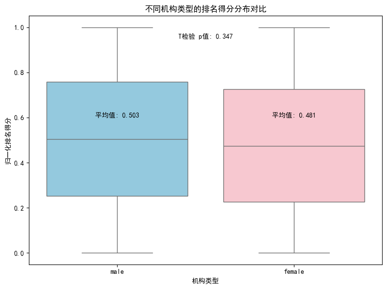

```python
# 箱线图，'pink', 'skyblue'表示不同性别的排名得分
def plot_rank_score_by_gender(df):
    import scipy.stats as stats
    plt.figure(figsize=(8, 6))
    ax = sns.boxplot(x='gener', y='rank_score', data=df, hue='gener', palette=['skyblue', 'pink'], legend=False)
    means = df.groupby('gener')['rank_score'].mean()
    means = means.reindex(['male', 'female'])
    # 字体位置y轴保持一致
    for i, (etype, mean) in enumerate(means.items()):
        plt.text(i, 0.6, f'平均值: {mean:.3f}', ha='center', color='black')

    plt.xlabel('机构类型')
    plt.ylabel('归一化排名得分')
    plt.title('不同机构类型的排名得分分布对比')

    types = df['gener'].unique()
    if len(types) == 2:
        group1 = df[df['gener'] == types[0]]['rank_score']
        group2 = df[df['gener'] == types[1]]['rank_score']
        stat, p_value = stats.ttest_ind(group1, group2, nan_policy='omit')
        print(f'T检验结果: statistic={stat}, p-value={p_value}')
        plt.text(0.5, max(df['rank_score']) * 0.95, f'T检验 p值: {p_value:.3}', ha='center')

    plt.tight_layout()
    plt.savefig('rank_score_by_gender.png')
    plt.show()

plot_rank_score_by_gender(df)
```

从图中可以看出，男女学者排名得分分布相似，均值差异不大。检验结果 p = 0.347 表明两性学者排名差异在统计上不显著，说明性别与学者排名得分之间没有明显相关性。

```python
df_drop = df_regions.dropna(subset=['employer_type'])
```

```python
df_drop
```

|  | domain | rank | name | gener | org | employer_type | region | id | region_clean | macro_region |
| --- | --- | --- | --- | --- | --- | --- | --- | --- | --- | --- |
| 0 | AAAI/IJCAI | 1 | Christian Szegedy | male | Google | Industry | United States | 1 | United States | North America |
| 1 | AAAI/IJCAI | 5 | Hado Philip Van Hasselt | male | Google | Industry | United States | 2 | United States | North America |
| 2 | AAAI/IJCAI | 1 | Sergey Ioffe | male | Google | Industry | United States | 3 | United States | North America |
| 3 | AAAI/IJCAI | 1 | Vincent Vanhoucke | male | Google | Industry | United States | 4 | United States | North America |
| 4 | AAAI/IJCAI | 9 | Feiping Nie | male | Northwest Polytechnic University | Academia | China | 5 | China | East Asia |
| ... | ... | ... | ... | ... | ... | ... | ... | ... | ... | ... |
| 1995 | Computer Networking | 12 | Stephen Stuart | male | Google | Industry | United States | 1996 | United States | North America |
| 1996 | Computer Networking | 77 | David A. Maltz | male | Microsoft | Industry | United States | 1997 | United States | North America |
| 1997 | Computer Networking | 45 | Gurudatta M. Parulkar | male | Intel Corporation | Industry | United States | 1998 | United States | North America |
| 1998 | Computer Networking | 45 | Bill Snow | male | Intel Corporation | Industry | United States | 1999 | United States | North America |
| 1999 | Computer Networking | 62 | Pavlin Radoslavov | male | Google | Industry | United States | 2000 | United States | North America |

1971 rows × 10 columns

```python
from pyecharts import options as opts
from pyecharts.charts import Sankey
import pandas as pd

# 节点列表
regions = df_drop['macro_region'].unique().tolist()
countries = df_drop['region_clean'].unique().tolist()
types_ = df_drop['employer_type'].unique().tolist()
genders = df_drop['gener'].unique().tolist()

nodes = regions + countries + types_

# 给性别节点加上数量标注
gender_counts = df_drop['gener'].value_counts()
gender_nodes = [f"{g} ({gender_counts[g]})" for g in genders]

nodes += gender_nodes

node_list = [{"name": n} for n in nodes]

# 节点索引
node_index = {n: i for i, n in enumerate(nodes)}

links = []

# 区域 -> 国家
region_country = df_drop.groupby(['macro_region','region_clean']).size().reset_index(name='value')
for _, row in region_country.iterrows():
    links.append({
        "source": row['macro_region'],
        "target": row['region_clean'],
        "value": int(row['value']),
        "itemStyle": {"color": "#5B8FF9"}  # 蓝色系
    })

# 国家 -> 机构类型
country_type = df_drop.groupby(['region_clean','employer_type']).size().reset_index(name='value')
for _, row in country_type.iterrows():
    color = "#61DDAA" if row['employer_type']=="Academia" else "#F6BD16"
    links.append({
        "source": row['region_clean'],
        "target": row['employer_type'],
        "value": int(row['value']),
        "itemStyle": {"color": color}
    })

# 机构类型 -> 性别
type_gender = df.groupby(['employer_type','gener']).size().reset_index(name='value')
for _, row in type_gender.iterrows():
    gender_label = f"{row['gener']} ({gender_counts[row['gener']]})"
    color = "#FF6F91" if row['gener']=="male" else "#FF9671"
    links.append({
        "source": row['employer_type'],
        "target": gender_label,
        "value": int(row['value']),
        "itemStyle": {"color": color}
    })


sankey = (
    Sankey()
    .add(
        "学者流向",
        nodes=node_list,
        links=links,
        linestyle_opt=opts.LineStyleOpts(opacity=0.6, curve=0.5, color="source"),
        label_opts=opts.LabelOpts(position="right"),
    )
    .set_global_opts(
        # 标题放在sankey图下方
        title_opts=opts.TitleOpts(title="AI 2000 学者综合结构（区域 → 国家 → 机构类型 → 性别）"),
        tooltip_opts=opts.TooltipOpts(trigger="item", formatter="{b}: {c}"), # 提示框显示节点或边的名称和值
    )
)


sankey.render_notebook()
```

```python
sankey.render("ai_scholars_sankey_diagram.html")
```

```
'C:\\Projects\\python\\AI2000\\ai_scholars_sankey_diagram.html'
```

北美地区尤其是美国学者数量最多；

学者主要集中在学界机构，产业界学者数量较少；

男性学者占绝大多数；

结合国家和区域 HHI 指数分析，学者分布具有明显的集中性，同时排名得分分布在各分支相对均衡。

## 4.总结

- 学者集中性：顶尖学者高度集中于少数机构、国家和区域（北美、美国、学界机构、男性占主导）。
- 机构类型影响有限：学界与产业界学者在排名得分上差异不显著，但机构类型分布存在结构差异。
- 性别不平衡明显：男性学者占绝对多数，男女比例差距在各个排名百分比中一致体现且变化不大，但性别与排名得分无显著相关性。
- 排名分布：领域内标准化排名显示，各分支学者排名较均衡，不受机构类型或性别的显著影响。

政策与科研启示：

- AI 学术资源集中在少数机构和国家，需要关注全球科研资源公平性
- 性别平衡仍有提升空间，尤其在产业界
- 可通过政策或合作促进区域间学术交流，提高非集中地区学者影响力